# XGBoost and XGBoost Tuned Models for Predicting Customer Churn

#### The questions we are asking:

How can we keep customers from leaving and going to a new service provider? What are customers most concerned about in their decision to leave the company?

#### This exhibition utilizes an **XGBoost** and a **Tuned XGBoost**, the Tuned XGBoost is *focused* on the **most significant variables**, and the *results* for both are *below*.

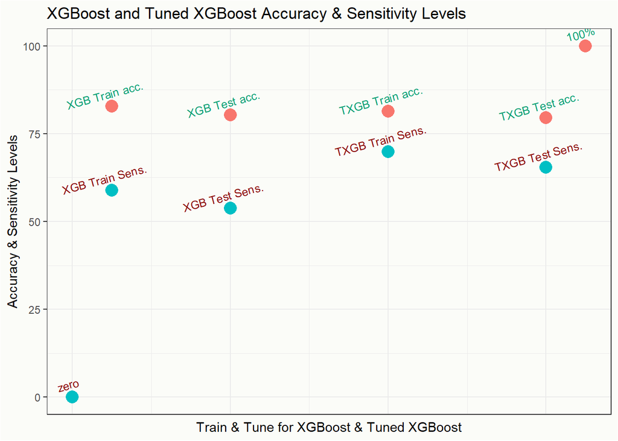

## Results With the XGB and XGB Tuned Models:

> With our **XGB Model** tuned up there was a *slight decrease* in accuracy  
> from **80.33%** to **79.62%**,  
> A **-0.71%** difference.  
> There was a *trade-off* for a significant increase in sensitivity,  
> from **53.83%** to **65.41%**,  
> A **11.58%** increase in ability to detect true positives.  
> Sensitivity = (True Positives)/(True Positives + False Negatives)

### This translates into the abilty *to predict if customers are going to leave*, and the most significant reasons those customers are likely to leave. This will help *reduce customer churn*, and **maintain/increase revenues**.

```
## *************** XGB Train & Test: Accuracy & Sensitivity ***************
```

```
## Train accuracy:    82.83 %
## Train sensitivity: 58.94 %
##
## Test  accuracy:    80.33 %
## Test  sensitivity: 53.83 %
```

```
## ************ XGB Tuned Train & Test: Accuracy & Sensitivity ************
```

```
## Tuned Train accuracy:    81.35 %
## Tuned Train sensitivity: 69.86 %
##
## Tuned Test  accuracy:    79.62 %
## Tuned Test  sensitivity: 65.41 %
```

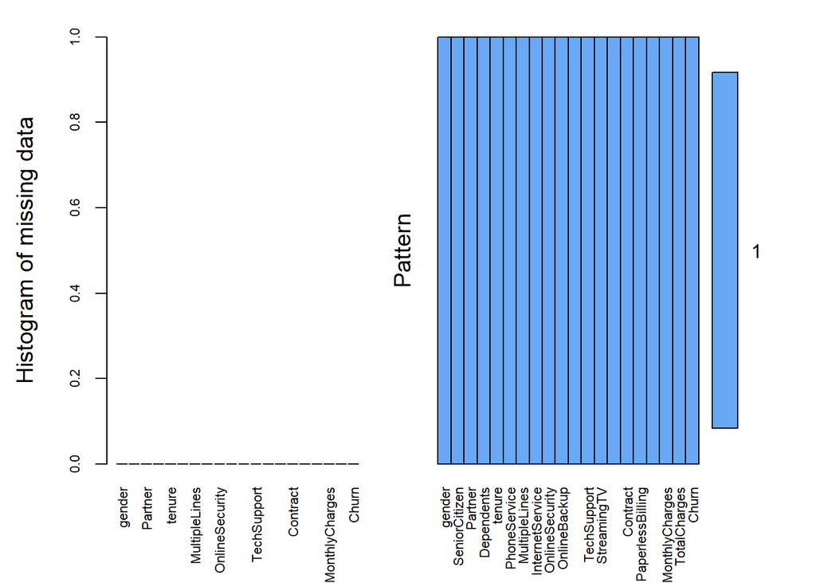

```
##
##  Variables sorted by number of missings:
##          Variable Count
##            gender     0
##     SeniorCitizen     0
##           Partner     0
##        Dependents     0
##            tenure     0
##      PhoneService     0
##     MultipleLines     0
##   InternetService     0
##    OnlineSecurity     0
##      OnlineBackup     0
##  DeviceProtection     0
##       TechSupport     0
##       StreamingTV     0
##   StreamingMovies     0
##          Contract     0
##  PaperlessBilling     0
##     PaymentMethod     0
##    MonthlyCharges     0
##      TotalCharges     0
##             Churn     0
```

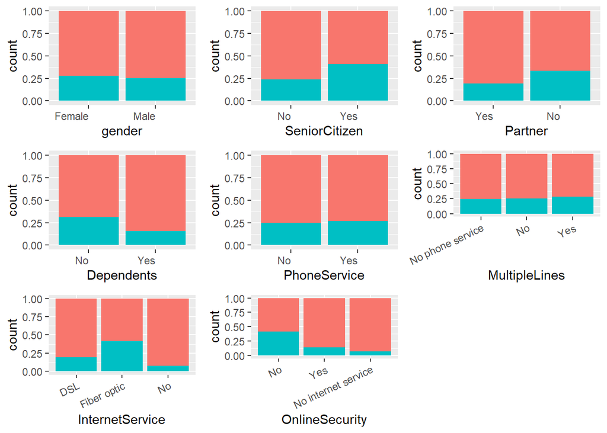

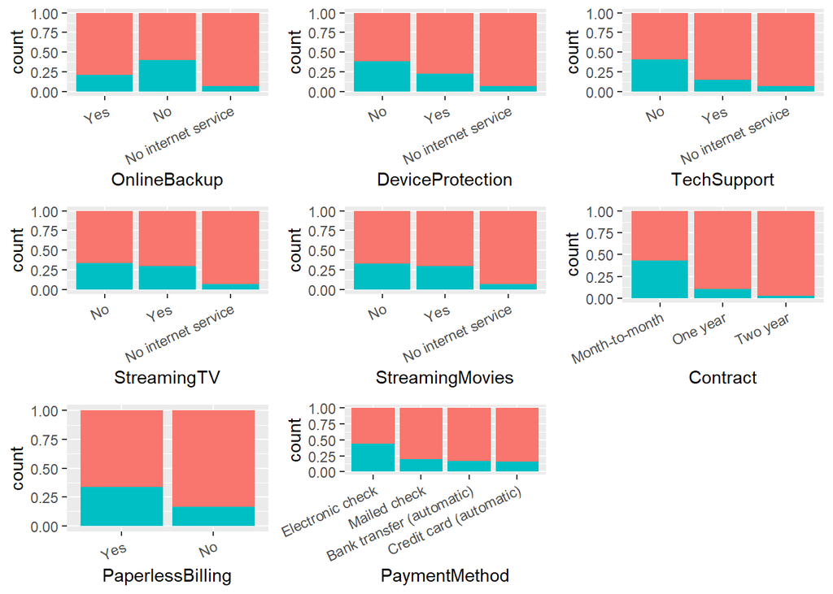

The report was completed in 15.8 seconds.